# Student Performance Predictor

Author

Shifa Panjwani

## Problem Statement

In the field of education, understanding the factors influencing student performance is critical for improving academic outcomes. This project aims to develop a predictive model to estimate students’ Math scores using the [**Student Performance Prediction**](https://www.kaggle.com/datasets/spscientist/students-performance-in-exams?datasetId=74977) dataset. The dataset contains various demographic and academic features, including **gender**, **race/ethnicity**, **parental education level**, **lunch type**, **test preparation course completion**, as well as **reading and writing scores**.

The primary objective is to analyze how these factors contribute to Math performance and create an accurate machine learning model that can predict Math scores.

**Key Goals:**

- Develop a regression-based predictive model to estimate Math scores
- Perform EDA to identify patterns and correlations
- Evaluate linear and KNN model performances using appropriate metrics (e.g., RMSE, R-squared)
- Identify the best model

This project will leverage various machine learning algorithms and evaluate their effectiveness to select the best-performing model. The results will offer valuable insights into the factors influencing Math achievement and suggest strategies for academic support.

## Data: Students Performance in Exams

There are 8 columns and 1000 rows. The primary variables of interest are:

- *`gender`:* Gender of the student
- *`race_ethnicity`*: Race/ethnicity of the student
- *`parental_level_of_education`*: Highest degree earned by student’s parents
- *`lunch`:* Type of lunch plan the student is registered for
- *`test_preparation_course`*: Whether they took a test preparation course
- *`math_score`*: Student’s math score
- *`reading_score`*: Student’s reading score
- *`writing_score`*: Student’s writing score

The ultimate goal will be to predict *`math_score`* using the other features.

## Loading Libraries

```r
library(tidyverse)
library(tidymodels)
library(ggplot2)
library(ISLR2)
library(dplyr)
library(readr)
library(knitr)
```

## Loading Dataset

```r
data <- read_csv('stud.csv')
kable(head(data))
```

| gender | race_ethnicity | parental_level_of_education | lunch | test_preparation_course | math_score | reading_score | writing_score |
| --- | --- | --- | --- | --- | --- | --- | --- |
| female | group B | bachelor’s degree | standard | none | 72 | 72 | 74 |
| female | group C | some college | standard | completed | 69 | 90 | 88 |
| female | group B | master’s degree | standard | none | 90 | 95 | 93 |
| male | group A | associate’s degree | free/reduced | none | 47 | 57 | 44 |
| male | group C | some college | standard | none | 76 | 78 | 75 |
| female | group B | associate’s degree | standard | none | 71 | 83 | 78 |

## Exploratory Data Analysis

### Missing Values

```r
sum(is.na(data))
```

```
[1] 0
```

### Near-Zero Variance & Lumping

This section checks the distribution of categorical variables in the dataset. The goal was to identify categories with near-zero variance (very few occurrences), however, none of the categories qualified for it. Hence, there’s no need for lumping.

```r
data |> count(gender) |> kable()
```

| gender | n |
| --- | --- |
| female | 518 |
| male | 482 |

```r
data |> count(race_ethnicity) |> kable()
```

| race_ethnicity | n |
| --- | --- |
| group A | 89 |
| group B | 190 |
| group C | 319 |
| group D | 262 |
| group E | 140 |

```r
data |> count(parental_level_of_education) |> kable()
```

| parental_level_of_education | n |
| --- | --- |
| associate’s degree | 222 |
| bachelor’s degree | 118 |
| high school | 196 |
| master’s degree | 59 |
| some college | 226 |
| some high school | 179 |

```r
data |> count(lunch) |> kable()
```

| lunch | n |
| --- | --- |
| free/reduced | 355 |
| standard | 645 |

```r
data |> count(test_preparation_course) |> kable()
```

| test_preparation_course | n |
| --- | --- |
| completed | 358 |
| none | 642 |

### Math Score vs. Gender

**Hypothesis**: Math scores would be quite similar for both genders.

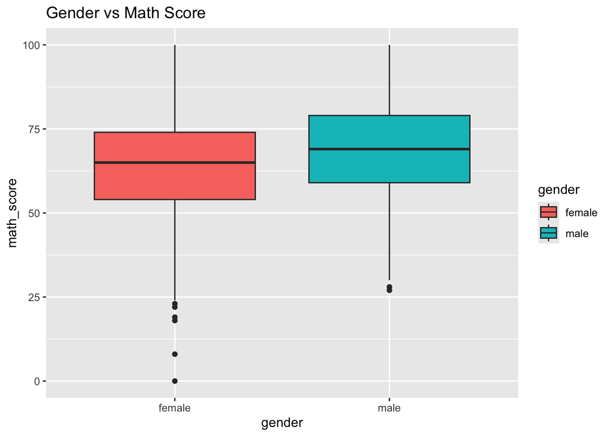

```r
ggplot(data, aes(x = gender, y = math_score, fill = gender)) +
  geom_boxplot() +
  labs(title = "Gender vs Math Score")
```

- Male students tend to score slightly better in math than female students.

### Math Score vs. Test Preparation Course

**Hypothesis**: Math scores would be higher for students who took the test preparation course.

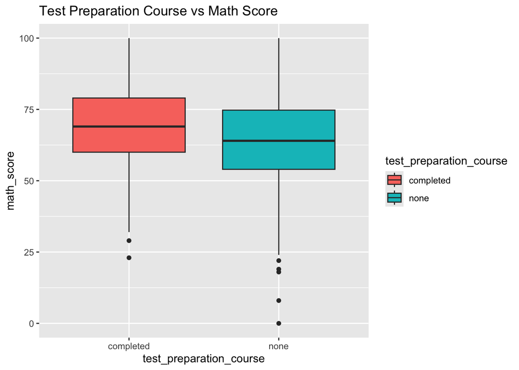

```r
ggplot(data, aes(x = test_preparation_course, y = math_score, fill = test_preparation_course)) +
  geom_boxplot() +
  labs(title = "Test Preparation Course vs Math Score")
```

- Students who had completed a test preparation course scored higher in math than those who had not taken it.

### Correlation Matrix

```r
correlation_matrix <- cor(data |>
                            select_if(is.numeric))
print(correlation_matrix)
```

```
              math_score reading_score writing_score
math_score     1.0000000     0.8175797     0.8026420
reading_score  0.8175797     1.0000000     0.9545981
writing_score  0.8026420     0.9545981     1.0000000
```

- Reading and Writing scores have a high positive correlation.
- Math scores, with each of Reading and Writing scores also have moderate positive correlations.

## Data Pre-processing

### Categorical Columns to Factors

This code converts all categorical columns in the dataset from ‘character’ to ‘factor’ type, to ensure they are treated appropriately during modeling.

```r
data <- data |>
  mutate(across(where(is.character), as.factor))
```

### Data Splitting

We split the data into train (70%) and test (30%) sets.

```r
set.seed(427)
data_split <- initial_split(data, prop = 0.7)
train_data <- training(data_split)
test_data <- testing(data_split)
```

- There are 1000 rows in this dataset.
- After a 70/30 split, there are 700 rows in training set and 300 in test set.

### Linear Regression Recipes

This section creates 3 different data pre-processing pipelines using the `recipes` package from `tidymodels` to prepare data for linear regression models. Each recipe applies various imputation, encoding and normalization techniques to handle missing values, categorical data, and scaling.

#### Recipe 1: Mean Imputation + Dummy Encoding + Normalization

- **Mean Imputation:** Missing numeric values are replaced with the mean of the respective columns.
- **Unknown Category Assignment:** Unknown levels in categorical variables are handled.
- **Dummy Encoding:** Categorical variables are converted into dummy (binary) variables for linear regression.
- **Linear Combination Check:** Multi-collinear functions are detected and removed.
- **Normalization:** Numeric features are scaled to have a mean of zero and standard deviation of one.

```r
recipe_lm1 <- recipe(math_score ~ ., data = train_data) |>
  step_impute_mean(all_numeric_predictors()) |>
  step_unknown(all_nominal_predictors()) |>
  step_dummy(all_nominal_predictors()) |>
  step_lincomb(all_predictors()) |>
  step_normalize(all_numeric_predictors())
```

#### Recipe 2: Median Imputation + Zero-Variance Removal + Ordinal Encoding

- **Median Imputation:** Missing numeric values are replaced with median of each column.
- **Zero-Variance Removal:** Features with zero or near-zero variance are removed.
- **Ordinal Encoding:** Categorical variables are encoded as integers based on their levels.

```r
recipe_lm2 <- recipe(math_score ~ ., data = train_data) |>
  step_impute_median(all_numeric_predictors()) |>
  step_unknown(all_nominal_predictors()) |>
  step_zv(all_predictors()) |>
  step_integer(all_nominal_predictors()) |>
  step_lincomb(all_predictors()) |>
  step_normalize(all_numeric_predictors())
```

#### Recipe 3: KNN Imputation + Lumping Rare Categories + Normalization

- **KNN Imputation:** Missing numeric values are imputed using the KNN method.
- **Lumping Rare Categories:** Categorical variables with a frequency below 5% are grouped into an ‘Other’ category.

```r
recipe_lm3 <- recipe(math_score ~ ., data = train_data) |>
  step_impute_knn(all_numeric_predictors()) |>
  step_unknown(all_nominal_predictors()) |>
  step_other(all_nominal_predictors(), threshold = 0.05) |>
  step_dummy(all_nominal_predictors()) |>
  step_lincomb(all_predictors()) |>
  step_zv(all_predictors()) |>
  step_normalize(all_numeric_predictors())
```

### KNN Recipes

This section creates 3 different data preprocessing pipelines using the ‘recipes’ package from tidymodels to prepare data for KNN regression models. Each recipe applies various imputation, encoding and normalization techniques to prepare data for effective model training.

#### Recipe 1: Mean Imputation + One-Hot Encoding + Zero-Variance Removal +Normalization

- **One-Hot Encoding:** Categorical variables are converted into multiple binary columns using ‘step_dummy’ with one-hot encoding.

```r
recipe_knn1 <- recipe(math_score ~ ., data = train_data) |>
  step_impute_mean(all_numeric_predictors()) |>
  step_unknown(all_nominal_predictors()) |>
  step_dummy(all_nominal_predictors(), one_hot = TRUE) |>
  step_zv(all_predictors()) |>
  step_normalize(all_numeric_predictors())
```

#### Recipe 2: Median Imputation + Lumping Rare Categories + Zero-Variance Removal + Normalization

```r
recipe_knn2 <- recipe(math_score ~ ., data = train_data) |>
  step_impute_median(all_numeric_predictors()) |>
  step_other(all_nominal_predictors(), threshold = 0.02) |>
  step_dummy(all_nominal_predictors(), one_hot = TRUE) |>
  step_zv(all_predictors()) |>
  step_normalize(all_numeric_predictors())
```

#### Recipe 3: KNN Imputation + Zero-Variance Removal + Normalization

```r
recipe_knn3 <- recipe(math_score ~ ., data = train_data) |>
  step_impute_knn(all_numeric_predictors()) |>
  step_unknown(all_nominal_predictors()) |>
  step_dummy(all_nominal_predictors(), one_hot = TRUE) |>
  step_zv(all_predictors()) |>
  step_normalize(all_numeric_predictors())
```

## Model Definition

This section defines the models that will be used for regression tasks. A Linear Regression model and 3 KNN models with different values for k are created.

### Linear Regression

This model will be used to establish a linear relationship between the features and the math scores.

```r
lm_model <- linear_reg() |>
  set_engine("lm")
```

### KNN Models

- *‘knn_model3’* uses 3 nearest neighbors for prediction, making it more sensitive to local patterns.
- *‘knn_model5’* uses 5 nearest neighbors, providing a balanced approach between accuracy and stability.
- *‘knn_model10’* uses 10 nearest neighbors, which may generalize better but could miss finer details.

```r
knn_model3 <- nearest_neighbor(neighbors = 3) |>
  set_engine("kknn") |>
  set_mode("regression")
knn_model5 <- nearest_neighbor(neighbors = 5) |>
  set_engine("kknn") |>
  set_mode("regression")
knn_model10 <- nearest_neighbor(neighbors = 10) |>
  set_engine("kknn") |>
  set_mode("regression")
```

## Workflow Creation

This section creates and organizes multiple workflows. Workflows are a convenient way to bundle together preprocessing recipes and models for streamlined model training and evaluation.

### Linear Regression Workflow Set

Since there’s only one model, each recipe is paired with it, forming 3 distinct workflows.

```r
lm_workflows <- workflow_set(
  preproc = list(
    "lm_recipe1" = recipe_lm1,
    "lm_recipe2" = recipe_lm2,
    "lm_recipe3" = recipe_lm3
  ),
  models = list(
    "lm_model" = lm_model
  ),
  cross = TRUE
)
```

### KNN Workflow Set

- The ‘cross = TRUE’ parameter ensures that all recipes are applied to each of the models, creating a comprehensive set of workflows.

```r
knn_workflows <- workflow_set(
  preproc = list(
    "knn_recipe1" = recipe_knn1,
    "knn_recipe2" = recipe_knn2,
    "knn_recipe3" = recipe_knn3
  ),
  models = list(
    "knn_3" = knn_model3,
    "knn_5" = knn_model5,
    "knn_10" = knn_model10
  ),
  cross = TRUE
)
```

### Combining All Workflows

Gathers all possible combinations of preprocessing recipes and models, providing a consolidated set of workflows for model training, validation and comparison.

```r
all_workflows <- lm_workflows |>
  bind_rows(knn_workflows)
```

## Cross-Validation & Model Evaluation

This section performs cross-validation to evaluate the performance of different models and preprocessing pipelines. It uses repeated k-fold cross-validation to ensure robust and reliable model reassessment.

**Cross-Validation:** Split the training data into 5 folds and repeat the process 5 times. It minimizes model bias and variance by averaging results across different folds.

**Evaluation Metrics:** Using RMSE and R-Squared to evaluate model performance.

**Workflow Mapping:** Applying all workflows to the cross-validation splits.

```r
set.seed(427)

cv_splits <- vfold_cv(train_data, v = 5, repeats = 5)
metrics <- metric_set(rmse, rsq)

cv_results <- workflow_map(
  all_workflows,
  resamples = cv_splits,
  metrics = metrics
)

cv_metrics <- cv_results |> collect_metrics()
```

## Visualization of Model Performance

### RMSE Plot

Visualizing Root Mean Squared Error values for each workflow, measuring the average error between predicted and actual Math scores. Lower RMSE indicates better model performance.

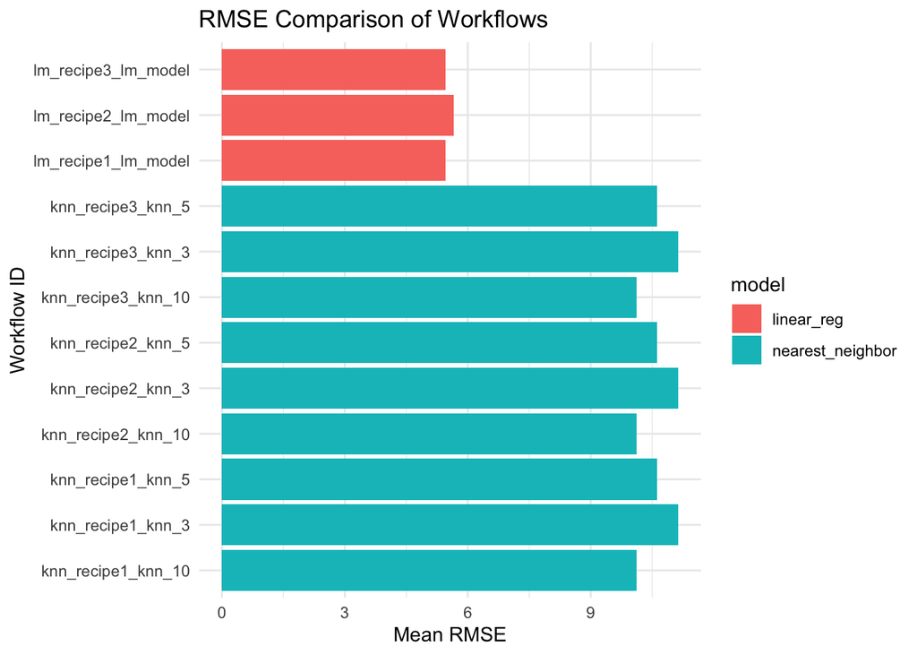

```r
ggplot(cv_metrics |> filter(.metric == "rmse"), aes(x = wflow_id, y = mean, fill = model)) +
  geom_col(position = "dodge") +
  coord_flip() +
  labs(
    title = "RMSE Comparison of Workflows",
    x = "Workflow ID",
    y = "Mean RMSE"
  ) +
  theme_minimal()
```

### R-Squared Plot

Visualizing the Mean R-Squared values for each workflow, showing how well the model explains the variance in Math scores. Higher R-squared indicates better model performance.

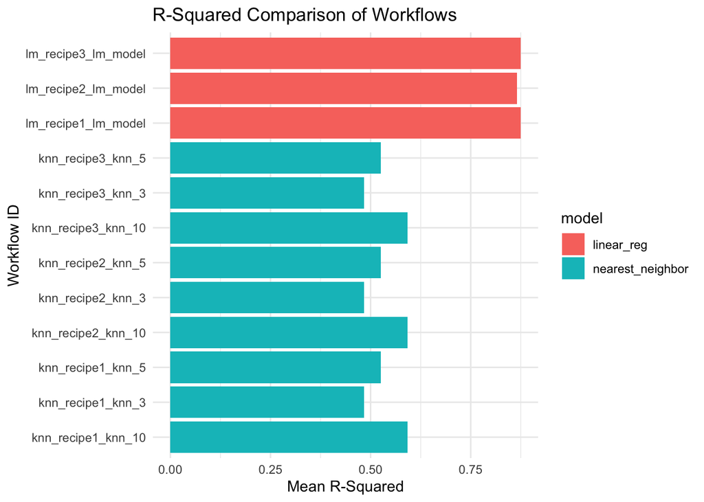

```r
ggplot(cv_metrics |> filter(.metric == "rsq"), aes(x = wflow_id, y = mean, fill = model)) +
  geom_col(position = "dodge") +
  coord_flip() +
  labs(
    title = "R-Squared Comparison of Workflows",
    x = "Workflow ID",
    y = "Mean R-Squared"
  ) +
  theme_minimal()
```

*lm_recipe1_lm_model* **is the our best performing model since it has the lowest RMSE and highest R-Squared.**

## Model Selection, Fitting & Evaluation

This section extracts the best_performing model, fits it to the data, and evaluates its performance on the test set using appropriate metrics.

```r
# Extract and Fit Best Model
best_workflow <- all_workflows |>
  extract_workflow("lm_recipe1_lm_model")

# Re-fit the model
set.seed(427)
data_split <- initial_split(data, prop = 0.7)
final_fit <- last_fit(best_workflow, split = data_split, metrics = metric_set(rmse, rsq))

# Evaluate on Test Set
test_metrics <- collect_metrics(final_fit)
test_metrics
```

```
# A tibble: 2 × 4
  .metric .estimator .estimate .config
  <chr>   <chr>          <dbl> <chr>
1 rmse    standard       5.33  Preprocessor1_Model1
2 rsq     standard       0.868 Preprocessor1_Model1
```

This step concludes the modeling process, offering a clear measure of the model’s predictive accuracy and effectiveness.